# INFSCI 2595 Final Project

Part 3A, Classification - Baseline Models

Zhenyu Li

2022-04-22

```r
library(tidyverse)
library(coefplot)
source("./scripts/utils.R")
theme_set(theme_linedraw())
```

```r
df <- readr::read_csv("./data/final_project_train.csv", col_names = TRUE)
sel_num <- df %>% select_if(is_double) %>% select(!rowid) %>% select(sort(names(.))) %>% colnames()
sel_num_in <- setdiff(sel_num, "response")
sel_cat <- df %>% select(!one_of(sel_num)) %>% select(!rowid) %>% colnames()
sel_cat_in <- setdiff(sel_cat, "outcome")
```

In this section, several baseline linear models are trained using `glm`.

- Models are compared based on AIC/BIC.
- Important features from models are discussed.

## Preprocessing

- For classification, the necessary preprocessing steps include:
  - Normalize the continuous inputs

```r
df_prep_cl <- df %>%
  mutate_if(is.character,as.factor) %>%
  select(-c(rowid,response)) %>%
  mutate(
    across(starts_with("x"), scale)
  ) %>%
  mutate(outcome = ifelse(outcome=="event",1,0))
```

## Model Fitting

**Create generalized linear models to fit the data.**

### Predefined Models

**Fit 6 predefined generalized linear models.**

1. Categorical variables only – linear additive
2. Continuous variables only – linear additive
3. All categorical and continuous variables – linear additive
4. Interact `region` with continuous inputs, do not include `customer`
5. Interact `customer` with continuous inputs, do not include `region`
6. All pairwise interactions of continuous inputs, do not include categorical inputs

Slice the data with certain inputs to facilitate model building.

```r
df_cat <- df_prep_cl %>% select(-all_of(sel_num_in))
df_num <- df_prep_cl %>% select(-all_of(sel_cat_in))
```

Fit models by providing formula.

```r
# fit the predefined models
mod_3A1 <- glm(outcome ~ ., binomial, df_cat)
mod_3A2 <- glm(outcome ~ ., binomial, df_num)
mod_3A3 <- glm(outcome ~ ., binomial, df_prep_cl)
mod_3A4 <- glm(outcome ~ (region) * (. -customer), binomial, df_prep_cl)
mod_3A5 <- glm(outcome ~ (customer) * (. -region), binomial, df_prep_cl)
mod_3A6 <- glm(outcome ~ (.)^2, binomial, df_num)
```

- When the feature space is large (`mod_3A5`, `mod_3A6`), we see some models result linear separability.
  - This is likely because of the expanded features.
  - Worth consider applying regularization to constrain the coefficients.

Get a quick comparison of models using information criterion.

```r
my_models <- mget(ls(pattern = "^mod_3A\\d+"))
calc_models_ic(my_models, logistic = T)
```

```
## # A tibble: 6 × 3
##   model     AIC   BIC
##   <chr>   <dbl> <dbl>
## 1 mod_3A1  644.  693.
## 2 mod_3A2  496.  650.
## 3 mod_3A3  489.  688.
## 4 mod_3A4  575. 1036.
## 5 mod_3A5 5718. 7074.
## 6 mod_3A6 1124. 3663.
```

- `mod_3A2`: Linear additive relationship of only continuous inputs got best BIC.
- `mod_3A3`: Linear additive relationship of all continuous and categorical inputs got best AIC.

### Custom Basis Models

**Fit 4 custom basis models.**

- From EDA, identify inputs that cause distinction of `region` by outcome event probability
  - `xs` index `03, 04, 05, 06`
  - `xw` index `01, 02, 03`

**1. Interact `region` with these inputs, keep linear additive for the rest.**

```r
mod_3Ac1 <- glm(
  outcome ~ . + region : (
   + xs_03 + xs_04 + xs_05 + xs_06
   + xw_01 + xw_02 + xw_03 ),
  binomial, data=df_prep_cl)
calc_models_ic(list(mod_3Ac1), T)
```

```
## # A tibble: 1 × 3
##   model   AIC   BIC
##   <chr> <dbl> <dbl>
## 1 1      507.  769.
```

**2. Interact these inputs, keep the rest linear additive.**

```r
mod_3Ac2 <- glm(
  outcome ~ . +
   ( xs_03 + xs_04 + xs_05 + xs_06) :
   ( xw_01 + xw_02 + xw_03 ),
  binomial, data=df_prep_cl)
calc_models_ic(list(mod_3Ac2), T)
```

```
## # A tibble: 1 × 3
##   model   AIC   BIC
##   <chr> <dbl> <dbl>
## 1 1      486.  739.
```

**3. Interact `customer` to these inputs, keep the rest linear additive.**

```r
mod_3Ac3 <- glm(
  outcome ~ . + customer : (
   + xs_03 + xs_04 + xs_05 + xs_06
   + xw_01 + xw_02 + xw_03 ),
  binomial, data=df_prep_cl)
calc_models_ic(list(mod_3Ac3), T)
```

```
## # A tibble: 1 × 3
##   model   AIC   BIC
##   <chr> <dbl> <dbl>
## 1 1      523.  975.
```

**4. Use pair-wise interaction for all inputs.**

```r
mod_3Ac4 <- glm(
  outcome ~ (.)^2,
  binomial, df_prep_cl)
calc_models_ic(list(mod_3Ac4), T)
```

```
## # A tibble: 1 × 3
##   model   AIC   BIC
##   <chr> <dbl> <dbl>
## 1 1     1352. 4406.
```

**Save the models to file.**

```r
my_models <- mget(ls(pattern = "^mod_3A"))
save_models(my_models)
```

## Conclusions

```r
mod_3A1 <- readr::read_rds("models/mod_3A1")
mod_3A2 <- readr::read_rds("models/mod_3A2")
mod_3A3 <- readr::read_rds("models/mod_3A3")
mod_3A4 <- readr::read_rds("models/mod_3A4")
mod_3A5 <- readr::read_rds("models/mod_3A5")
mod_3A6 <- readr::read_rds("models/mod_3A6")
mod_3Ac1 <- readr::read_rds("models/mod_3Ac1")
mod_3Ac2 <- readr::read_rds("models/mod_3Ac2")
mod_3Ac3 <- readr::read_rds("models/mod_3Ac3")
mod_3Ac4 <- readr::read_rds("models/mod_3Ac4")
```

### Model Comparison

**Print out the model metrics.**

```r
my_models <- mget(ls(pattern = "^mod_3A"))
calc_models_ic(my_models, T) %>% knitr::kable()
```

| model | AIC | BIC |
| --- | --- | --- |
| mod_3A1 | 643.7403 | 693.4347 |
| mod_3A2 | 496.4571 | 650.0579 |
| mod_3A3 | 488.7758 | 687.5533 |
| mod_3A4 | 575.4990 | 1036.3015 |
| mod_3A5 | 5718.1988 | 7073.5002 |
| mod_3A6 | 1124.0000 | 3662.9313 |
| mod_3Ac1 | 507.0421 | 769.0670 |
| mod_3Ac2 | 485.9412 | 738.9308 |
| mod_3Ac3 | 523.0259 | 974.7931 |
| mod_3Ac4 | 1352.0000 | 4405.9458 |

- I will use information criterion (AIC/BIC) for model selection since models are developed from training set without resampling.
- None of the custom basis models was able to drive down BIC, and only one `mod_3Ac2` barely made the AIC lower.
- Best models selected:
  - Based on the BIC, select `mod_3A2`.
  - Based on balance of the two, select `mod_3A3`
  - Based on the AIC, select `mod_3Ac2`.

### Coefficient Plot

**Visualize the coefficient summaries for the top 3 models.**

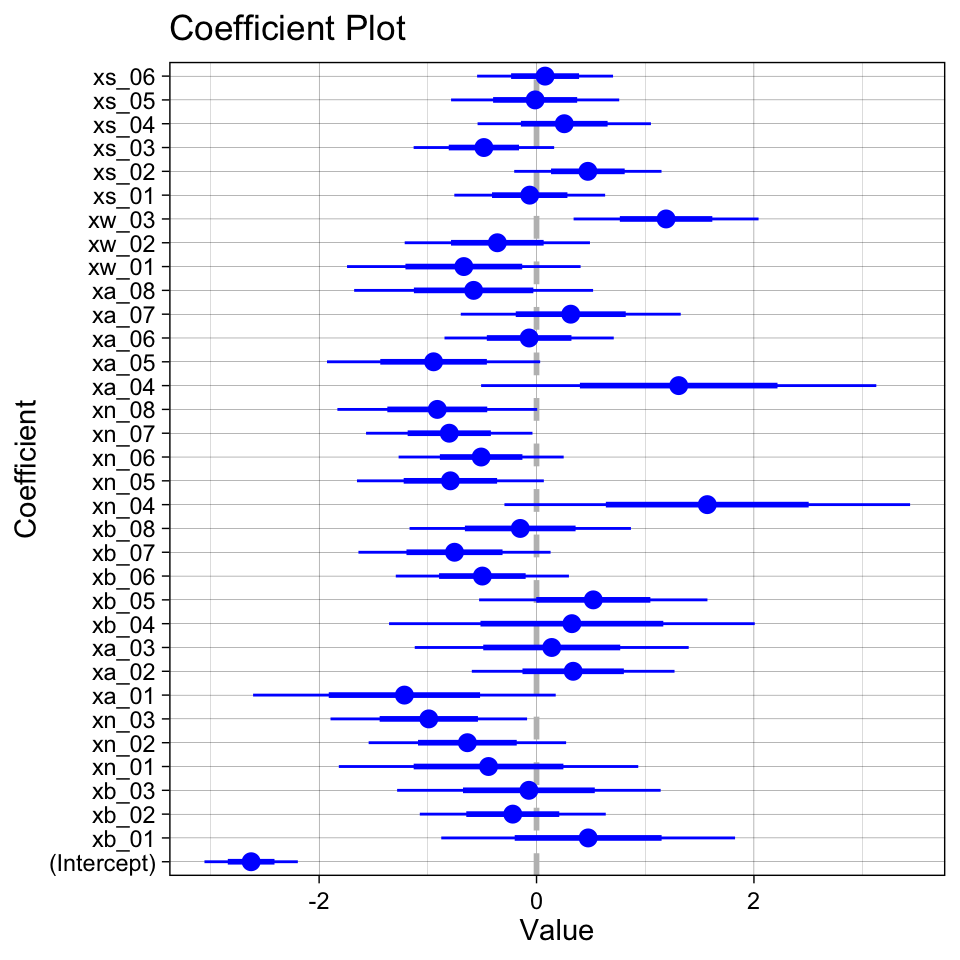

```r
coefplot(mod_3A2)
```

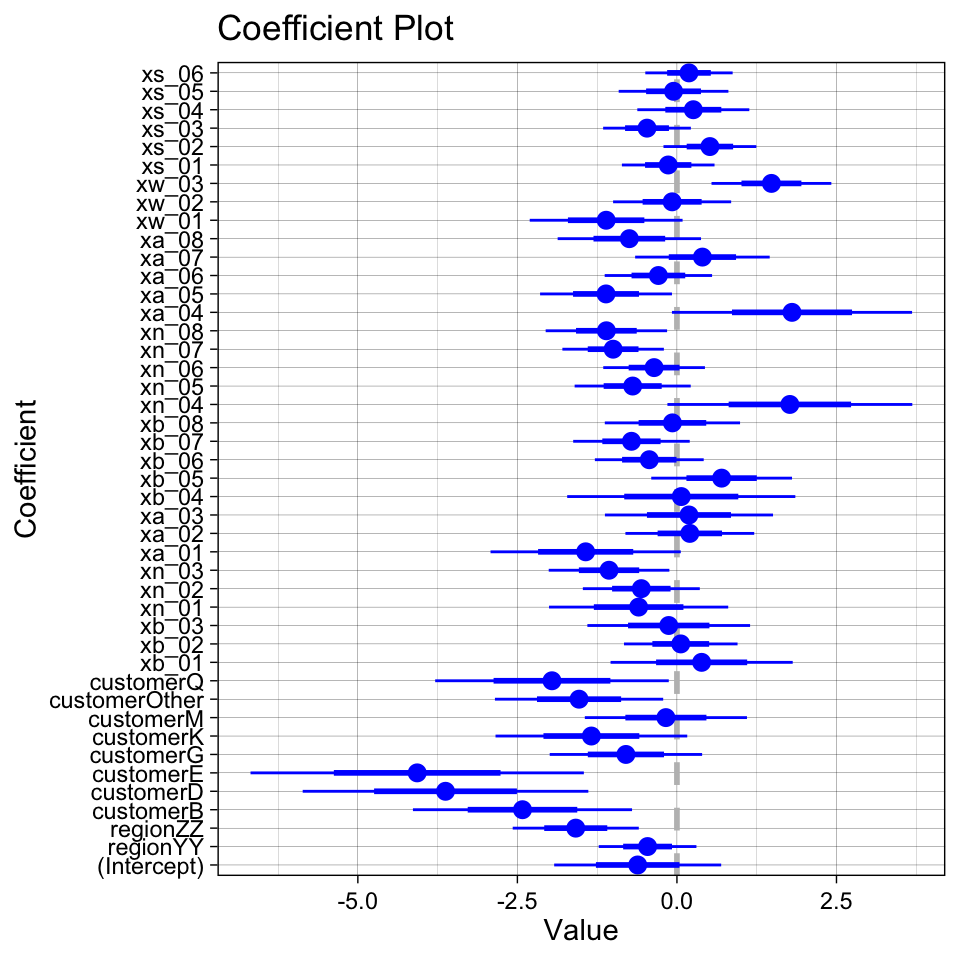

```r
coefplot(mod_3A3)
```

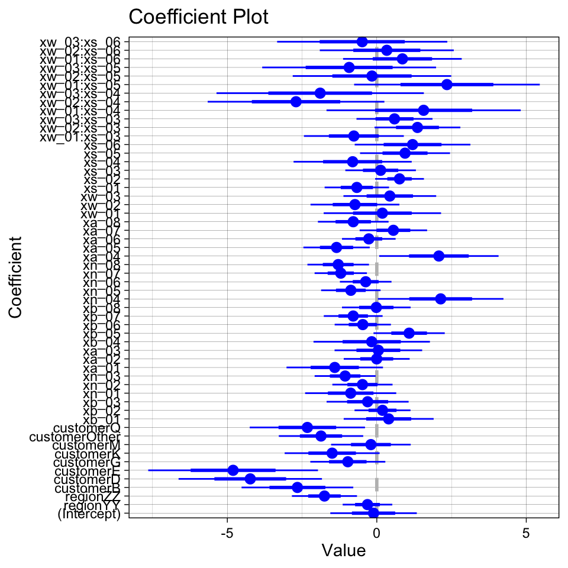

```r
coefplot(mod_3Ac2)
```

- Each model contains some significant coefficients, but it looks like majority of them are non-significant.
- The uncertainty for the coefficients are larger than the regression models.

### Important Features

```r
pull_lm_coefs_signif(mod_3A2) %>% knitr::kable()
```

| coef | score |
| --- | --- |
| xw_03 | 2.801544 |
| xn_03 | 2.192352 |
| xn_07 | 2.097708 |
| xn_08 | 1.986843 |
| xa_05 | 1.931933 |
| xn_05 | 1.843822 |
| xa_01 | 1.746410 |
| xb_07 | 1.707520 |
| xn_04 | 1.683453 |
| xs_03 | 1.498692 |

```r
pull_lm_coefs_signif(mod_3A3) %>% knitr::kable()
```

| coef | score |
| --- | --- |
| customerD | 3.240680 |
| regionZZ | 3.210027 |
| xw_03 | 3.154306 |
| customerE | 3.117011 |
| customerB | 2.819364 |
| xn_07 | 2.514627 |
| customerOther | 2.326980 |
| xn_08 | 2.323954 |
| xn_03 | 2.251088 |
| xa_05 | 2.151058 |

```r
pull_lm_coefs_signif(mod_3Ac2) %>% knitr::kable()
```

| coef | score |
| --- | --- |
| customerD | 3.529891 |
| customerE | 3.385868 |
| regionZZ | 3.216964 |
| customerB | 2.841960 |
| xn_07 | 2.755660 |
| customerOther | 2.643944 |
| xn_08 | 2.507976 |
| xa_05 | 2.426492 |
| customerQ | 2.409721 |
| xa_04 | 2.080652 |

- For continuous inputs, potential important ones are `xw_03`, `xn_03`, `xn_07`, `xn_08`, `xa_05`.
- For categorical inputs, it appears `customer` is critical in determining the `outcome`.